# Bank_marketing_campaign

#### BUSINESS PROBLEM:

Improve marketing campaign of a Portuguese bank by analyzing their past marketing campaign data and recommending which customer to target for term deposits. By developing such a prediction algorithm, the bank can better target its customers and better channelize its marketing efforts.

#### MACHINE LEARNING PROBLEM:

Classification problem to predict if a customer will opt for Term Deposit or not.

#### EVALUATION METRIC:

Recall for the positive class (Not to miss out the potential customer for term deposits)

### Mount the Google Drive

```python
import pandas as pd

from google.colab import drive

drive.mount('/content/gdrive')
```

### Import the required Libraries

```python
# import the required libraries

import pandas as pd
import numpy as np

import matplotlib.pyplot as plt

import warnings
warnings.filterwarnings('ignore')

from sklearn.metrics import classification_report
```

### Custom Class for Feature Importance on sklearn pipelines

```python
# Code ref: https://towardsdatascience.com/extracting-plotting-feature-names-importance-from-scikit-learn-pipelines-eb5bfa6a31f4

import numpy as np
import pandas as pd
from sklearn.compose import ColumnTransformer
from sklearn.pipeline import Pipeline
from sklearn.utils.validation import check_is_fitted
import plotly.express as px


class FeatureImportance:

    """

    Extract & Plot the Feature Names & Importance Values from a Scikit-Learn Pipeline.

    The input is a Pipeline that starts with a ColumnTransformer & ends with a regression or classification model.
    As intermediate steps, the Pipeline can have any number or no instances from sklearn.feature_selection.
    Note:
    If the ColumnTransformer contains Pipelines and if one of the transformers in the Pipeline is adding completely new columns,
    it must come last in the pipeline. For example, OneHotEncoder, MissingIndicator & SimpleImputer(add_indicator=True) add columns
    to the dataset that didn't exist before, so there should come last in the Pipeline.


    Parameters
    ----------
    pipeline : a Scikit-learn Pipeline class where the a ColumnTransformer is the first element and model estimator is the last element
    verbose : a boolean. Whether to print all of the diagnostics. Default is False.

    Attributes
    __________
    column_transformer_features :  A list of the feature names created by the ColumnTransformer prior to any selectors being applied
    transformer_list : A list of the transformer names that correspond with the `column_transformer_features` attribute
    discarded_features : A list of the features names that were not selected by a sklearn.feature_selection instance.
    discarding_selectors : A list of the selector names corresponding with the `discarded_features` attribute
    feature_importance :  A Pandas Series containing the feature importance values and feature names as the index.
    plot_importances_df : A Pandas DataFrame containing the subset of features and values that are actually displaced in the plot.
    feature_info_df : A Pandas DataFrame that aggregates the other attributes. The index is column_transformer_features. The transformer column contains the transformer_list.
        value contains the feature_importance values. discarding_selector contains discarding_selectors & is_retained is a Boolean indicating whether the feature was retained.



    """
    def __init__(self, pipeline, verbose=False):
        self.pipeline = pipeline
        self.verbose = verbose


    def get_feature_names(self, verbose=None):

        """
        Get the column names from the a ColumnTransformer containing transformers & pipelines
        Parameters
        ----------
        verbose : a boolean indicating whether to print summaries.
            default = False
        Returns
        -------
        a list of the correct feature names
        Note:
        If the ColumnTransformer contains Pipelines and if one of the transformers in the Pipeline is adding completely new columns,
        it must come last in the pipeline. For example, OneHotEncoder, MissingIndicator & SimpleImputer(add_indicator=True) add columns
        to the dataset that didn't exist before, so there should come last in the Pipeline.
        Inspiration: https://github.com/scikit-learn/scikit-learn/issues/12525
        """

        if verbose is None:
            verbose = self.verbose

        if verbose: print('''\n\n---------\nRunning get_feature_names\n---------\n''')

        column_transformer = self.pipeline[0]
        assert isinstance(column_transformer, ColumnTransformer), "Input isn't a ColumnTransformer"
        check_is_fitted(column_transformer)

        new_feature_names, transformer_list = [], []

        for i, transformer_item in enumerate(column_transformer.transformers_):

            transformer_name, transformer, orig_feature_names = transformer_item
            orig_feature_names = list(orig_feature_names)

            if verbose:
                print('\n\n', i, '. Transformer/Pipeline: ', transformer_name, ',',
                      transformer.__class__.__name__, '\n')
                print('\tn_orig_feature_names:', len(orig_feature_names))

            if transformer == 'drop':

                continue

            if isinstance(transformer, Pipeline):
                # if pipeline, get the last transformer in the Pipeline
                transformer = transformer.steps[-1][1]

            if hasattr(transformer, 'get_feature_names'):

                if 'input_features' in transformer.get_feature_names.__code__.co_varnames:

                    names = list(transformer.get_feature_names(orig_feature_names))

                else:

                    names = list(transformer.get_feature_names())

            elif hasattr(transformer,'indicator_') and transformer.add_indicator:
                # is this transformer one of the imputers & did it call the MissingIndicator?

                missing_indicator_indices = transformer.indicator_.features_
                missing_indicators = [orig_feature_names[idx] + '_missing_flag'\
                                      for idx in missing_indicator_indices]
                names = orig_feature_names + missing_indicators

            elif hasattr(transformer,'features_'):
                # is this a MissingIndicator class?
                missing_indicator_indices = transformer.features_
                missing_indicators = [orig_feature_names[idx] + '_missing_flag'\
                                      for idx in missing_indicator_indices]

            else:

                names = orig_feature_names

            if verbose:
                print('\tn_new_features:', len(names))
                print('\tnew_features:\n', names)

            new_feature_names.extend(names)
            transformer_list.extend([transformer_name] * len(names))

        self.transformer_list, self.column_transformer_features = transformer_list,\
                                                                    new_feature_names
```

```python
        return new_feature_names


    def get_selected_features(self, verbose=None):
        """
        Get the Feature Names that were retained after Feature Selection (sklearn.feature_selection)
        Parameters
        ----------
        verbose : a boolean indicating whether to print summaries. default = False
        Returns
        -------
        a list of the selected feature names
        """

        if verbose is None:
            verbose = self.verbose

        assert isinstance(self.pipeline, Pipeline), "Input isn't a Pipeline"

        features = self.get_feature_names()

        if verbose: print('\n\n---------\nRunning get_selected_features\n---------\n')

        all_discarded_features, discarding_selectors = [], []

        for i, step_item in enumerate(self.pipeline.steps[:]):

            step_name, step = step_item

            if hasattr(step, 'get_support'):

                if verbose: print('\nStep ', i, ": ", step_name, ',',
                                  step.__class__.__name__, '\n')

                check_is_fitted(step)

                feature_mask_dict = dict(zip(features, step.get_support()))

                features = [feature for feature, is_retained in feature_mask_dict.items()\
                            if is_retained]

                discarded_features = [feature for feature, is_retained in feature_mask_dict.items()\
                                      if not is_retained]

                all_discarded_features.extend(discarded_features)
                discarding_selectors.extend([step_name] * len(discarded_features))


                if verbose:
                    print(f'\t{len(features)} retained, {len(discarded_features)} discarded')
                    if len(discarded_features) > 0:
                        print('\n\tdiscarded_features:\n\n', discarded_features)

        self.discarded_features, self.discarding_selectors = all_discarded_features,\
                                                                discarding_selectors

        return features

    def get_feature_importance(self):

        """
        Creates a Pandas Series where values are the feature importance values from the model and feature names are set as the index.

        This Series is stored in the `feature_importance` attribute.
        Returns
        -------
        A pandas Series containing the feature importance values and feature names as the index.

        """

        assert isinstance(self.pipeline, Pipeline), "Input isn't a Pipeline"

        features = self.get_selected_features()

        assert hasattr(self.pipeline[-1], 'feature_importances_'),\
            "The last element in the pipeline isn't an estimator with a feature_importances_ attribute"

        importance_values = self.pipeline[-1].feature_importances_

        assert len(features) == len(importance_values),\
            "The number of feature names & importance values doesn't match"

        feature_importance = pd.Series(importance_values, index=features)
        self.feature_importance = feature_importance

        # create feature_info_df
        column_transformer_df =\
            pd.DataFrame(dict(transformer=self.transformer_list),
                         index=self.column_transformer_features)

        discarded_features_df =\
            pd.DataFrame(dict(discarding_selector=self.discarding_selectors),
                         index=self.discarded_features)

        importance_df = self.feature_importance.rename('value').to_frame()

        self.feature_info_df = \
            column_transformer_df\
            .join([importance_df, discarded_features_df])\
            .assign(is_retained = lambda df: ~df.value.isna())


        return feature_importance


    def plot(self, top_n_features=100, rank_features=True, max_scale=True,
             display_imp_values=True, display_imp_value_decimals=1,
             height_per_feature=25, orientation='h', width=750, height=None,
             str_pad_width=15, yaxes_tickfont_family='Courier New',
             yaxes_tickfont_size=15):
        """
        Plot the Feature Names & Importances
        Parameters
        ----------
        top_n_features : the number of features to plot, default is 100
        rank_features : whether to rank the features with integers, default is True
        max_scale : Should the importance values be scaled by the maximum value & mulitplied by 100?  Default is True.
        display_imp_values : Should the importance values be displayed? Default is True.
        display_imp_value_decimals : If display_imp_values is True, how many decimal places should be displayed. Default is 1.
        height_per_feature : if height is None, the plot height is calculated by top_n_features * height_per_feature.
        This allows all the features enough space to be displayed
        orientation : the plot orientation, 'h' (default) or 'v'
        width :  the width of the plot, default is 500
        height : the height of the plot, the default is top_n_features * height_per_feature
        str_pad_width : When rank_features=True, this number of spaces to add between the rank integer and feature name.
            This will enable the rank integers to line up with each other for easier reading.
            Default is 15. If you have long feature names, you can increase this number to make the integers line up more.
            It can also be set to 0.
        yaxes_tickfont_family : the font for the feature names. Default is Courier New.
        yaxes_tickfont_size : the font size for the feature names. Default is 15.
        Returns
        -------
        plot
        """
        if height is None:
            height = top_n_features * height_per_feature

        # prep the data

        all_importances = self.get_feature_importance()
        n_all_importances = len(all_importances)

        plot_importances_df =\
            all_importances\
            .nlargest(top_n_features)\
            .sort_values()\
            .to_frame('value')\
            .rename_axis('feature')\
            .reset_index()
```

```python
        if max_scale:
            plot_importances_df['value'] = \
                                plot_importances_df.value.abs() /\
                                plot_importances_df.value.abs().max() * 100

        self.plot_importances_df = plot_importances_df.copy()

        if len(all_importances) < top_n_features:
            title_text = 'All Feature Importances'
        else:
            title_text = f'Top {top_n_features} (of {n_all_importances}) Feature Importances'

        if rank_features:
            padded_features = \
                plot_importances_df.feature\
                .str.pad(width=str_pad_width)\
                .values

            ranked_features =\
                plot_importances_df.index\
                .to_series()\
                .sort_values(ascending=False)\
                .add(1)\
                .astype(str)\
                .str.cat(padded_features, sep='. ')\
                .values

            plot_importances_df['feature'] = ranked_features

        if display_imp_values:
            text = plot_importances_df.value.round(display_imp_value_decimals)
        else:
            text = None

        # create the plot

        fig = px.bar(plot_importances_df,
                     x='value',
                     y='feature',
                     orientation=orientation,
                     width=width,
                     height=height,
                     text=text)
        fig.update_layout(title_text=title_text, title_x=0.5)
        fig.update(layout_showlegend=False)
        fig.update_yaxes(tickfont=dict(family=yaxes_tickfont_family,
                                       size=yaxes_tickfont_size),
                         title='')
        fig.show()
```

### Custom Function for Classification report comparision between train & test

```python
def classifcation_report_train_test(y_train, y_train_pred, y_test, y_test_pred):

    print('''
            =========================================
               CLASSIFICATION REPORT FOR TRAIN DATA
            =========================================
            ''')
    print(classification_report(y_train, y_train_pred))

    print('''
            =========================================
               CLASSIFICATION REPORT FOR TEST DATA
            =========================================
            ''')
    print(classification_report(y_test, y_test_pred))
```

### Read the Datasets

```python
df= pd.read_csv('/content/gdrive/MyDrive/Academics/Batch-89/7405 /casestudy/bank-additional-full.csv')
df_test = pd.read_csv('/content/gdrive/MyDrive/Academics/Batch-89/7405 /casestudy/test.csv')
```

### Data Exploration

```python
df.shape
```

```
(41188, 22)
```

```python
df.sample(4)
```

|  | customer_no | age | job | marital | education | credit_default | housing | loan | contact | contacted_month | day_of_week | duration | campaign | pdays | previous | poutcome | emp_var_rate | cons_price_idx | cons_conf_idx | euribor3m | nr_employed | y |
| --- | --- | --- | --- | --- | --- | --- | --- | --- | --- | --- | --- | --- | --- | --- | --- | --- | --- | --- | --- | --- | --- | --- |
| 6345 | 6346 | 50 | admin. | married | high.school | no | yes | no | telephone | may | tue | 20 | 19 | 999 | 0 | nonexistent | 1.1 | 93.994 | -36.4 | 4.857 | 5191.0 | no |
| 15740 | 15741 | 46 | services | married | high.school | unknown | no | yes | cellular | jul | mon | 336 | 4 | 999 | 0 | nonexistent | 1.4 | 93.918 | -42.7 | 4.960 | 5228.1 | no |
| 34175 | 34176 | 57 | blue-collar | married | basic.6y | unknown | no | no | cellular | may | wed | 97 | 5 | 999 | 0 | nonexistent | -1.8 | 92.893 | -46.2 | 1.281 | 5099.1 | no |
| 29463 | 29464 | 35 | admin. | divorced | high.school | no | unknown | unknown | cellular | apr | mon | 214 | 1 | 999 | 1 | failure | -1.8 | 93.075 | -47.1 | 1.405 | 5099.1 | no |

```python
df_test.sample(4)
```

|  | customer_no | age | job | marital | education | credit_default | housing | loan | contact | contacted_month | day_of_week | duration | campaign | pdays | previous | poutcome | emp_var_rate | cons_price_idx | cons_conf_idx | euribor3m | nr_employed |
| --- | --- | --- | --- | --- | --- | --- | --- | --- | --- | --- | --- | --- | --- | --- | --- | --- | --- | --- | --- | --- | --- |
| 1607 | 37076 | 33 | technician | single | university.degree | no | yes | no | cellular | jul | thu | 359 | 2 | 999 | 0 | nonexistent | -2.9 | 92.469 | -33.6 | 1.018 | 5076.2 |
| 169 | 19227 | 39 | technician | single | university.degree | no | yes | no | cellular | aug | wed | 224 | 1 | 999 | 0 | nonexistent | 1.4 | 93.444 | -36.1 | 4.967 | 5228.1 |
| 4013 | 23317 | 48 | admin. | married | university.degree | no | yes | yes | cellular | aug | wed | 254 | 5 | 999 | 0 | nonexistent | 1.4 | 93.444 | -36.1 | 4.964 | 5228.1 |
| 4095 | 34512 | 46 | blue-collar | married | basic.9y | unknown | yes | no | cellular | may | thu | 386 | 3 | 999 | 0 | nonexistent | -1.8 | 92.893 | -46.2 | 1.266 | 5099.1 |

```python
print(df.shape)
print(df_test.shape)
```

```
(41188, 22)
(4119, 21)
```

```python
df.y.value_counts(normalize=True)
```

```
no     0.887346
yes    0.112654
Name: y, dtype: float64
```

#### Check Unique values of all the column

```python
for i in df.columns:
    print(i, ':', len(df[i].unique()))
    print(df[i].unique())
    print('==='*25)
```

```
customer_no : 41188
[    1     2     3 ... 41186 41187 41188]
===========================================================================
age : 78
[56 57 37 40 45 59 41 24 25 29 35 54 46 50 39 30 55 49 34 52 58 32 38 44
 42 60 53 47 51 48 33 31 43 36 28 27 26 22 23 20 21 61 19 18 70 66 76 67
 73 88 95 77 68 75 63 80 62 65 72 82 64 71 69 78 85 79 83 81 74 17 87 91
 86 98 94 84 92 89]
===========================================================================
job : 12
['housemaid' 'services' 'admin.' 'blue-collar' 'technician' 'retired'
 'management' 'unemployed' 'self-employed' 'unknown' 'entrepreneur'
 'student']
===========================================================================
marital : 4
['married' 'single' 'divorced' 'unknown']
===========================================================================
education : 9
['basic.4y' 'high.school' 'basic.6y' 'basic.9y' 'professional.course'
 'unknown' 'university.degree' 'phd' 'illiterate']
===========================================================================
credit_default : 3
['no' 'unknown' 'yes']
===========================================================================
housing : 3
['no' 'yes' 'unknown']
===========================================================================
loan : 3
['no' 'yes' 'unknown']
===========================================================================
contact : 2
['telephone' 'cellular']
===========================================================================
contacted_month : 10
['may' 'jun' 'jul' 'aug' 'oct' 'nov' 'dec' 'mar' 'apr' 'sep']
===========================================================================
day_of_week : 5
['mon' 'tue' 'wed' 'thu' 'fri']
===========================================================================
duration : 1544
```

[output cut: 50 more lines]

```
 0.692 0.695 0.697 0.699 0.701 0.702 0.704 0.711 0.713 0.723 0.727 0.729
 0.732 0.748 0.761 0.767 0.782 0.79  0.793 0.802 0.81  0.822 0.827 0.835
 0.84  0.846 0.87  0.876 0.885 0.889 0.893 0.896 0.898 0.9   0.904 0.905
 0.895 0.894 0.891 0.89  0.888 0.886 0.882 0.88  0.878 0.877 0.942 0.953
 0.956 0.959 0.965 0.972 0.977 0.982 0.985 0.987 0.993 1.    1.008 1.016
 1.025 1.032 1.037 1.043 1.045 1.047 1.05  1.049 1.046 1.041 1.04  1.039
 1.035 1.03  1.031 1.028]
===========================================================================
nr_employed : 11
[5191.  5228.1 5195.8 5176.3 5099.1 5076.2 5017.5 5023.5 5008.7 4991.6
 4963.6]
===========================================================================
y : 2
['no' 'yes']
===========================================================================
```

#### Inspect the training and testing datasets

```python
def inspect_data(data):
    return pd.DataFrame({"Data Type":data.dtypes,"No of Levels":data.apply(lambda x: x.nunique(),axis=0), "Levels":data.apply(lambda x: str(x.unique()),axis=0)})
```

```python
inspect_data(df)
```

|  | Data Type | No of Levels | Levels |
| --- | --- | --- | --- |
| customer_no | int64 | 41188 | [ 1 2 3 ... 41186 41187 41188] |
| age | int64 | 78 | [56 57 37 40 45 59 41 24 25 29 35 54 46 50 39 ... |
| job | object | 12 | ['housemaid' 'services' 'admin.' 'blue-collar'... |
| marital | object | 4 | ['married' 'single' 'divorced' 'unknown'] |
| education | object | 9 | ['basic.4y' 'high.school' 'basic.6y' 'basic.9y... |
| credit_default | object | 3 | ['no' 'unknown' 'yes'] |
| housing | object | 3 | ['no' 'yes' 'unknown'] |
| loan | object | 3 | ['no' 'yes' 'unknown'] |
| contact | object | 2 | ['telephone' 'cellular'] |
| contacted_month | object | 10 | ['may' 'jun' 'jul' 'aug' 'oct' 'nov' 'dec' 'ma... |
| day_of_week | object | 5 | ['mon' 'tue' 'wed' 'thu' 'fri'] |
| duration | int64 | 1544 | [ 261 149 226 ... 1246 1556 1868] |
| campaign | int64 | 42 | [ 1 2 3 4 5 6 7 8 9 10 11 12 13 19 18 ... |
| pdays | int64 | 27 | [999 6 4 3 5 1 0 10 7 8 9 ... |
| previous | int64 | 8 | [0 1 2 3 4 5 6 7] |
| poutcome | object | 3 | ['nonexistent' 'failure' 'success'] |
| emp_var_rate | float64 | 10 | [ 1.1 1.4 -0.1 -0.2 -1.8 -2.9 -3.4 -3. -1.7 ... |
| cons_price_idx | float64 | 26 | [93.994 94.465 93.918 93.444 93.798 93.2 92.... |
| cons_conf_idx | float64 | 26 | [-36.4 -41.8 -42.7 -36.1 -40.4 -42. -45.9 -50... |
| euribor3m | float64 | 316 | [4.857 4.856 4.855 4.859 4.86 4.858 4.864 4.8... |
| nr_employed | float64 | 11 | [5191. 5228.1 5195.8 5176.3 5099.1 5076.2 501... |
| y | object | 2 | ['no' 'yes'] |

```python
inspect_data(df_test)
```

|  | Data Type | No of Levels | Levels |
| --- | --- | --- | --- |
| customer_no | int64 | 3916 | [15725 28030 17730 ... 35366 5342 30710] |
| age | int64 | 69 | [36 39 54 43 26 45 42 32 56 58 52 46 37 53 31 ... |
| job | object | 12 | ['technician' 'services' 'management' 'blue-co... |
| marital | object | 4 | ['married' 'single' 'divorced' 'unknown'] |
| education | object | 8 | ['basic.4y' 'high.school' 'university.degree' ... |
| credit_default | object | 2 | ['no' 'unknown'] |
| housing | object | 3 | ['no' 'yes' 'unknown'] |
| loan | object | 3 | ['no' 'yes' 'unknown'] |
| contact | object | 3 | ['cellular' 'telephone' 'Email'] |
| contacted_month | object | 10 | ['jul' 'apr' 'jun' 'aug' 'may' 'nov' 'sep' 'de... |
| day_of_week | object | 5 | ['mon' 'thu' 'tue' 'fri' 'wed'] |
| duration | int64 | 807 | [ 854 598 218 226 72 58 168 426 74 ... |
| campaign | int64 | 30 | [ 1 2 3 5 18 11 4 10 6 8 13 9 7 12 16 ... |
| pdays | int64 | 18 | [999 7 3 4 6 5 10 8 12 2 0 ... |
| previous | int64 | 6 | [0 2 4 1 3 5] |
| poutcome | object | 3 | ['nonexistent' 'failure' 'success'] |
| emp_var_rate | float64 | 10 | [ 1.4 -1.8 1.1 -2.9 -0.1 -1.1 -3. -1.7 -3.4 ... |
| cons_price_idx | float64 | 26 | [93.918 93.075 94.465 93.444 93.994 92.893 92.... |
| cons_conf_idx | float64 | 26 | [-42.7 -47.1 -41.8 -36.1 -36.4 -46.2 -40.8 -42... |
| euribor3m | float64 | 229 | [4.96 1.483 4.961 4.957 4.865 4.962 4.963 4.8... |
| nr_employed | float64 | 11 | [5228.1 5099.1 5191. 5076.2 5195.8 4963.6 502... |

```python
df.shape
```

```
(41188, 22)
```

#### Compare the datasets for the number of values that are missing in training and testing dataset

```python
### The function compare_train_test compares the training and testing dataset to check if the same set of
### categorical values are present in both the dataframes.
def compare_train_test(train_data, test_data):
    train_levels = train_data.apply(lambda x: set(x.unique()),axis=0)
    test_levels = test_data.apply(lambda x: set(x.unique()),axis=0)
    extra = []
    missing = []
    for x1,x2 in zip(train_levels, test_levels):
        missing.append(x1-x2)
        extra.append(x2-x1)

    return pd.DataFrame({"Train Data Type":train_data.dtypes, "Test Data Type":test_data.dtypes,
                         "Train #Levels":train_data.apply(lambda x: x.unique().shape[0],axis=0), "Test #Levels":test_data.apply(lambda x: x.unique().shape[0],axis=0),
                         "Test Missing":missing, "Test Extra":extra})
```

```python
compare_train_test(df.drop('y', axis=1), df_test)
```

|  | Train Data Type | Test Data Type | Train #Levels | Test #Levels | Test Missing | Test Extra |
| --- | --- | --- | --- | --- | --- | --- |
| customer_no | int64 | int64 | 41188 | 3916 | {1, 2, 3, 4, 5, 6, 7, 8, 9, 10, 11, 12, 14, 15... | {} |
| age | int64 | int64 | 78 | 69 | {98, 81, 17, 18, 87, 89, 92, 94, 95} | {} |
| job | object | object | 12 | 12 | {} | {} |
| marital | object | object | 4 | 4 | {} | {} |
| education | object | object | 9 | 8 | {phd} | {} |
| credit_default | object | object | 3 | 2 | {yes} | {} |
| housing | object | object | 3 | 3 | {} | {} |
| loan | object | object | 3 | 3 | {} | {} |
| contact | object | object | 2 | 3 | {} | {Email} |
| contacted_month | object | object | 10 | 10 | {} | {} |
| day_of_week | object | object | 5 | 5 | {} | {} |
| duration | int64 | int64 | 1544 | 807 | {1, 2, 3, 2053, 2055, 2062, 2078, 2087, 2089, ... | {} |
| campaign | int64 | int64 | 42 | 30 | {33, 35, 37, 39, 40, 41, 42, 22, 23, 56, 25, 29} | {} |
| pdays | int64 | int64 | 27 | 18 | {1, 16, 17, 19, 20, 21, 22, 25, 26} | {} |
| previous | int64 | int64 | 8 | 6 | {6, 7} | {} |
| poutcome | object | object | 3 | 3 | {} | {} |
| emp_var_rate | float64 | float64 | 10 | 10 | {} | {} |
| cons_price_idx | float64 | float64 | 26 | 26 | {} | {} |
| cons_conf_idx | float64 | float64 | 26 | 26 | {} | {} |
| euribor3m | float64 | float64 | 316 | 229 | {0.996, 0.927, 0.677, 3.9010000000000002, 4.93... | {} |
| nr_employed | float64 | float64 | 11 | 11 | {} | {} |

### List of numeric columns

```python
### numerical
num_cols = list(df.select_dtypes(exclude=['object']))
print(num_cols)
```

```
['customer_no', 'age', 'duration', 'campaign', 'pdays', 'previous', 'emp_var_rate', 'cons_price_idx', 'cons_conf_idx', 'euribor3m', 'nr_employed']
```

```python
df[num_cols].groupby(df.y).mean()
```

| y | customer_no | age | duration | campaign | pdays | previous | emp_var_rate | cons_price_idx | cons_conf_idx | euribor3m | nr_employed |
| --- | --- | --- | --- | --- | --- | --- | --- | --- | --- | --- | --- |
| no | 19354.359719 | 39.911185 | 220.844807 | 2.633085 | 984.113878 | 0.132374 | 0.248875 | 93.603757 | -40.593097 | 3.811491 | 5176.166600 |
| yes | 30362.742888 | 40.913147 | 553.191164 | 2.051724 | 792.035560 | 0.492672 | -1.233448 | 93.354386 | -39.789784 | 2.123135 | 5095.115991 |

```python
pd.crosstab(df.campaign, df.y).apply(lambda r: r/r.sum(), axis=1)
```

| y campaign | no | yes |
| --- | --- | --- |
| 1 | 0.869629 | 0.130371 |
| 2 | 0.885430 | 0.114570 |
| 3 | 0.892529 | 0.107471 |
| 4 | 0.906073 | 0.093927 |
| 5 | 0.924953 | 0.075047 |
| 6 | 0.923391 | 0.076609 |
| 7 | 0.939587 | 0.060413 |
| 8 | 0.957500 | 0.042500 |
| 9 | 0.939929 | 0.060071 |
| 10 | 0.946667 | 0.053333 |
| 11 | 0.932203 | 0.067797 |
| 12 | 0.976000 | 0.024000 |
| 13 | 0.956522 | 0.043478 |
| 14 | 0.985507 | 0.014493 |
| 15 | 0.960784 | 0.039216 |
| 16 | 1.000000 | 0.000000 |
| 17 | 0.931034 | 0.068966 |
| 18 | 1.000000 | 0.000000 |
| 19 | 1.000000 | 0.000000 |
| 20 | 1.000000 | 0.000000 |
| 21 | 1.000000 | 0.000000 |
| 22 | 1.000000 | 0.000000 |
| 23 | 0.937500 | 0.062500 |
| 24 | 1.000000 | 0.000000 |
| 25 | 1.000000 | 0.000000 |
| 26 | 1.000000 | 0.000000 |
| 27 | 1.000000 | 0.000000 |
| 28 | 1.000000 | 0.000000 |
| 29 | 1.000000 | 0.000000 |
| 30 | 1.000000 | 0.000000 |
| 31 | 1.000000 | 0.000000 |
| 32 | 1.000000 | 0.000000 |
| 33 | 1.000000 | 0.000000 |
| 34 | 1.000000 | 0.000000 |
| 35 | 1.000000 | 0.000000 |
| 37 | 1.000000 | 0.000000 |
| 39 | 1.000000 | 0.000000 |
| 40 | 1.000000 | 0.000000 |
| 41 | 1.000000 | 0.000000 |
| 42 | 1.000000 | 0.000000 |
| 43 | 1.000000 | 0.000000 |
| 56 | 1.000000 | 0.000000 |

### List of Categorical columns

```python
### categorical
cat_cols = list(df.select_dtypes(include=['object']))
cat_cols
```

```
['job',
 'marital',
 'education',
 'credit_default',
 'housing',
 'loan',
 'contact',
 'contacted_month',
 'day_of_week',
 'poutcome',
 'y']
```

```python
for i in cat_cols:
    print('=='*10)
    print(i)
    print('=='*10)
    display(pd.crosstab(df[i], df.y, normalize=True))
```

```
====================
job
====================
```

| y job | no | yes |
| --- | --- | --- |
| admin. | 0.220210 | 0.032825 |
| blue-collar | 0.209187 | 0.015490 |
| entrepreneur | 0.032340 | 0.003011 |
| housemaid | 0.023162 | 0.002574 |
| management | 0.063028 | 0.007963 |
| retired | 0.031223 | 0.010537 |
| self-employed | 0.030883 | 0.003618 |
| services | 0.088521 | 0.007842 |
| student | 0.014567 | 0.006677 |
| technician | 0.145989 | 0.017724 |
| unemployed | 0.021123 | 0.003496 |
| unknown | 0.007114 | 0.000898 |

```
====================
marital
====================
```

| y marital | no | yes |
| --- | --- | --- |
| divorced | 0.100418 | 0.011557 |
| married | 0.543751 | 0.061474 |
| single | 0.241527 | 0.039332 |
| unknown | 0.001651 | 0.000291 |

```
====================
education
====================
```

| y education | no | yes |
| --- | --- | --- |
| basic.4y | 0.090997 | 0.010391 |
| basic.6y | 0.051083 | 0.004564 |
| basic.9y | 0.135282 | 0.011484 |
| high.school | 0.205982 | 0.025032 |
| illiterate | 0.000340 | 0.000097 |
| phd | 0.000073 | 0.000000 |
| professional.course | 0.112848 | 0.014446 |
| university.degree | 0.254880 | 0.040546 |
| unknown | 0.035860 | 0.006094 |

```
====================
credit_default
====================
```

| y credit_default | no | yes |
| --- | --- | --- |
| no | 0.689303 | 0.101899 |
| unknown | 0.197970 | 0.010756 |
| yes | 0.000073 | 0.000000 |

```
====================
housing
====================
```

| y housing | no | yes |
| --- | --- | --- |
| no | 0.402933 | 0.049189 |
| unknown | 0.021438 | 0.002598 |
| yes | 0.462975 | 0.060867 |

```
====================
loan
====================
```

| y loan | no | yes |
| --- | --- | --- |
| no | 0.730795 | 0.093474 |
| unknown | 0.021438 | 0.002598 |
| yes | 0.135112 | 0.016582 |

```
====================
contact
====================
```

| y contact | no | yes |
| --- | --- | --- |
| cellular | 0.541201 | 0.093547 |
| telephone | 0.346145 | 0.019108 |

```
====================
contacted_month
====================
```

| y contacted_month | no | yes |
| --- | --- | --- |
| apr | 0.050816 | 0.013086 |
| aug | 0.134092 | 0.015903 |
| dec | 0.002258 | 0.002161 |
| jul | 0.158420 | 0.015757 |
| jun | 0.115543 | 0.013572 |
| mar | 0.006555 | 0.006701 |
| may | 0.312785 | 0.021511 |
| nov | 0.089468 | 0.010100 |
| oct | 0.009784 | 0.007648 |
| sep | 0.007624 | 0.006215 |

```
====================
day_of_week
====================
```

| y day_of_week | no | yes |
| --- | --- | --- |
| fri | 0.169491 | 0.020540 |
| mon | 0.186146 | 0.020564 |
| thu | 0.183986 | 0.025371 |
| tue | 0.173279 | 0.023138 |
| wed | 0.174444 | 0.023041 |

```
====================
poutcome
====================
```

| y poutcome | no | yes |
| --- | --- | --- |
| failure | 0.088545 | 0.014689 |
| nonexistent | 0.787171 | 0.076260 |
| success | 0.011630 | 0.021705 |

```
====================
y
====================
```

| y | no | yes |
| --- | --- | --- |
| no | 0.887346 | 0.000000 |
| yes | 0.000000 | 0.112654 |

### Drop Unnecessary variables

```python
df.drop("customer_no", axis = 1, inplace= True)
df_test.drop("customer_no", axis = 1, inplace= True)
```

```python
df.columns
```

```
Index(['age', 'job', 'marital', 'education', 'credit_default', 'housing',
       'loan', 'contact', 'contacted_month', 'day_of_week', 'duration',
       'campaign', 'pdays', 'previous', 'poutcome', 'emp_var_rate',
       'cons_price_idx', 'cons_conf_idx', 'euribor3m', 'nr_employed', 'y'],
      dtype='object')
```

### DataType Conversions

```python
cat_cols = ['job', 'marital', 'education', 'credit_default', 'housing', 'loan',  'contacted_month', 'day_of_week', 'poutcome']
num_cols = list(df.drop('y',axis=1).columns.difference(cat_cols))
```

```python
df[cat_cols] = df[cat_cols].astype('category')
df_test[cat_cols] = df_test[cat_cols].astype('category')
```

```python
df[['contact']].value_counts()
```

```
contact
cellular     26144
telephone    15044
dtype: int64
```

```python
df.columns
```

```
Index(['age', 'job', 'marital', 'education', 'credit_default', 'housing',
       'loan', 'contact', 'contacted_month', 'day_of_week', 'duration',
       'campaign', 'pdays', 'previous', 'poutcome', 'emp_var_rate',
       'cons_price_idx', 'cons_conf_idx', 'euribor3m', 'nr_employed', 'y'],
      dtype='object')
```

```python
df.dtypes
```

```
age                   int64
job                category
marital            category
education          category
credit_default     category
housing            category
loan               category
contact              object
contacted_month    category
day_of_week        category
duration              int64
campaign              int64
pdays                 int64
previous              int64
poutcome           category
emp_var_rate        float64
cons_price_idx      float64
cons_conf_idx       float64
euribor3m           float64
nr_employed         float64
y                    object
dtype: object
```

### Missing Value Analysis & Imputation

```python
# print columns with missing values
df.isnull().sum()

# note that the missing values are given as 'unknown' so they will not be shown using isnull() function
```

[output not shown]

```python
df_test.isnull().sum()
```

[output not shown]

```python
pd.crosstab(df.job, df.education)
```

| education job | basic.4y | basic.6y | basic.9y | high.school | illiterate | phd | professional.course | university.degree | unknown |
| --- | --- | --- | --- | --- | --- | --- | --- | --- | --- |
| admin. | 77 | 151 | 499 | 3329 | 1 | 0 | 363 | 5753 | 249 |
| blue-collar | 2318 | 1426 | 3623 | 878 | 8 | 2 | 453 | 94 | 452 |
| entrepreneur | 137 | 71 | 210 | 234 | 2 | 1 | 135 | 610 | 56 |
| housemaid | 474 | 77 | 94 | 174 | 1 | 0 | 59 | 139 | 42 |
| management | 100 | 85 | 166 | 298 | 0 | 0 | 89 | 2063 | 123 |
| retired | 597 | 75 | 145 | 276 | 3 | 0 | 241 | 285 | 98 |
| self-employed | 93 | 25 | 220 | 118 | 3 | 0 | 168 | 765 | 29 |
| services | 132 | 226 | 388 | 2682 | 0 | 0 | 218 | 173 | 150 |
| student | 26 | 13 | 99 | 357 | 0 | 0 | 43 | 170 | 167 |
| technician | 58 | 87 | 384 | 873 | 0 | 0 | 3320 | 1809 | 212 |
| unemployed | 112 | 34 | 186 | 259 | 0 | 0 | 142 | 262 | 19 |
| unknown | 52 | 22 | 31 | 37 | 0 | 0 | 12 | 45 | 131 |

```python
df['job'][df['age']>60].value_counts()
```

```
retired          678
housemaid         54
admin.            47
technician        34
management        30
unknown           21
blue-collar       20
self-employed      9
entrepreneur       8
unemployed         7
services           2
student            0
Name: job, dtype: int64
```

Inferring education from jobs : From the cross-tabulation, it can be seen that people with management jobs usually have a university degree. Hence wherever 'job' = management and 'education' = unknown, we can replace 'education' with 'university.degree'. Similarly, 'job' = 'services' --> 'education' = 'high.school' and 'job' = 'housemaid' --> 'education' = 'basic.4y'.

Inferring jobs from education : If 'education' = 'basic.4y' or 'basic.6y' or 'basic.9y' then the 'job' is usually 'blue-collar'. If 'education' = 'professional.course', then the 'job' = 'technician'.

Inferring jobs from age : As we see, if 'age' > 60, then the 'job' is 'retired,' which makes sense.

```python
def impute_cols(df):
    df.loc[(df['age']>60) & (df['job']=='unknown'), 'job'] = 'retired'
    df.loc[(df['education']=='unknown') & (df['job']=='management'), 'education'] = 'university.degree'
    df.loc[(df['education']=='unknown') & (df['job']=='services'), 'education'] = 'high.school'
    df.loc[(df['education']=='unknown') & (df['job']=='housemaid'), 'education'] = 'basic.4y'
    df.loc[(df['job'] == 'unknown') & (df['education']=='basic.4y'), 'job'] = 'blue-collar'
    df.loc[(df['job'] == 'unknown') & (df['education']=='basic.6y'), 'job'] = 'blue-collar'
    df.loc[(df['job'] == 'unknown') & (df['education']=='basic.9y'), 'job'] = 'blue-collar'
    df.loc[(df['job']=='unknown') & (df['education']=='professional.course'), 'job'] = 'technician'
    return df
```

```python
df= impute_cols(df)
```

```python
df_test = impute_cols(df_test)
```

```python
pd.crosstab(df.job, df.education)
```

| education job | basic.4y | basic.6y | basic.9y | high.school | illiterate | phd | professional.course | university.degree | unknown |
| --- | --- | --- | --- | --- | --- | --- | --- | --- | --- |
| admin. | 77 | 151 | 499 | 3329 | 1 | 0 | 363 | 5753 | 249 |
| blue-collar | 2366 | 1448 | 3654 | 878 | 8 | 2 | 453 | 94 | 452 |
| entrepreneur | 137 | 71 | 210 | 234 | 2 | 1 | 135 | 610 | 56 |
| housemaid | 516 | 77 | 94 | 174 | 1 | 0 | 59 | 139 | 0 |
| management | 100 | 85 | 166 | 298 | 0 | 0 | 89 | 2186 | 0 |
| retired | 601 | 75 | 145 | 276 | 3 | 0 | 243 | 286 | 112 |
| self-employed | 93 | 25 | 220 | 118 | 3 | 0 | 168 | 765 | 29 |
| services | 132 | 226 | 388 | 2832 | 0 | 0 | 218 | 173 | 0 |
| student | 26 | 13 | 99 | 357 | 0 | 0 | 43 | 170 | 167 |
| technician | 58 | 87 | 384 | 873 | 0 | 0 | 3330 | 1809 | 212 |
| unemployed | 112 | 34 | 186 | 259 | 0 | 0 | 142 | 262 | 19 |
| unknown | 0 | 0 | 0 | 37 | 0 | 0 | 0 | 44 | 117 |

```python
def drawhist(df,feature):
    plt.hist(df[feature])
```

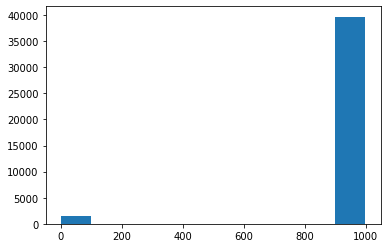

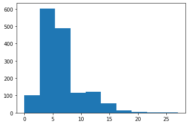

```python
drawhist(df,'pdays')
plt.show()

plt.hist(df.loc[df.pdays != 999, 'pdays'])
plt.show()
```

```python
pd.crosstab(df['pdays'],df['poutcome'])
```

| poutcome pdays | failure | nonexistent | success |
| --- | --- | --- | --- |
| 0 | 0 | 0 | 15 |
| 1 | 0 | 0 | 26 |
| 2 | 0 | 0 | 61 |
| 3 | 4 | 0 | 435 |
| 4 | 2 | 0 | 116 |
| 5 | 4 | 0 | 42 |
| 6 | 25 | 0 | 387 |
| 7 | 15 | 0 | 45 |
| 8 | 6 | 0 | 12 |
| 9 | 24 | 0 | 40 |
| 10 | 7 | 0 | 45 |
| 11 | 3 | 0 | 25 |
| 12 | 13 | 0 | 45 |
| 13 | 8 | 0 | 28 |
| 14 | 5 | 0 | 15 |
| 15 | 9 | 0 | 15 |
| 16 | 2 | 0 | 9 |
| 17 | 5 | 0 | 3 |
| 18 | 5 | 0 | 2 |
| 19 | 1 | 0 | 2 |
| 20 | 1 | 0 | 0 |
| 21 | 2 | 0 | 0 |
| 22 | 0 | 0 | 3 |
| 25 | 1 | 0 | 0 |
| 26 | 0 | 0 | 1 |
| 27 | 0 | 0 | 1 |
| 999 | 4110 | 35563 | 0 |

As we can see from the above table, the majority of the values for 'pdays' are missing. The majority of these missing values occur when the 'poutcome' is 'non-existent'. This means that the majority of the values in 'pdays' are missing because the customer was never contacted before. To deal with this variable, we removed the numerical variable 'pdays' and replaced it with categorical variables with following categories: p_days_missing, pdays_less_5, pdays_bet_5_15, and pdays_greater_15.

```python
#Add new categorical variables to our dataframe.
df['pdays_missing'] = 0
df['pdays_less_5'] = 0
df['pdays_greater_15'] = 0
df['pdays_bet_5_15'] = 0
df['pdays_missing'][df['pdays']==999] = 1
df['pdays_less_5'][df['pdays']<5] = 1
df['pdays_greater_15'][(df['pdays']>15) & (df['pdays']<999)] = 1
df['pdays_bet_5_15'][(df['pdays']>=5)&(df['pdays']<=15)]= 1
df_dropped_pdays = df.drop('pdays', axis=1);
```

```python
df_test['pdays_missing'] = 0
df_test['pdays_less_5'] = 0
df_test['pdays_greater_15'] = 0
df_test['pdays_bet_5_15'] = 0
df_test['pdays_missing'][df_test['pdays']==999] = 1
df_test['pdays_less_5'][df_test['pdays']<5] = 1
df_test['pdays_greater_15'][(df_test['pdays']>15) & (df_test['pdays']<999)] = 1
df_test['pdays_bet_5_15'][(df_test['pdays']>=5)&(df_test['pdays']<=15)]= 1
df_test_dropped_pdays = df_test.drop('pdays', axis=1);
```

```python
df = df_dropped_pdays.replace('unknown', np.nan)
df_test = df_test_dropped_pdays.replace('unknown', np.nan)
```

```python
df['y'].replace({'no':0,'yes':1},inplace=True)
```

### Sklearn pipelines

Pipelines are a way to streamline a lot of the routine processes, encapsulating little pieces of logic into one function call, which makes it easier to actually do modeling instead just writing a bunch of code.

Pipelines are set up with the fit/transform/predict functionality, so you can fit a whole pipeline to the training data and transform to the test data, without having to do it individually for each thing you do. Super convenienent, right??

In single sentence a Pipeline is a Pipeline of transforms with a final estimator.

Steps to follow to create a pipeline

Step 1) Fetch the numerical and categorical columns

Step 2) Create a transformer/pipeline for numerical attributes

```
Create a list of tuples where each tuple represents the operation to be performed on numerical attributes
```

Step 3) Create a transformer/pipeline for categorical attributes

```
Create a list of tuples where each tuple represent the operation to be performed on categorical attributes
```

Step 4) Create a ColumnTransformer which merges both the numerical and categorical transformers

Step5) Create a final pipeline object which includes the ColumnTransformer and an estimator (an algorithm to be build on dataset)

Step6) (optional) Create a GridSearchCV object with pipeline as one of the inputs along with hyperparameter grid and Cross validation object

Step7) Apply fit() on train data and predict() on test data

```python
from sklearn.compose import ColumnTransformer
from sklearn.datasets import fetch_openml
from sklearn.pipeline import Pipeline
from sklearn.impute import SimpleImputer
from sklearn.preprocessing import StandardScaler, OneHotEncoder
from sklearn.linear_model import LogisticRegression
from sklearn.model_selection import train_test_split, GridSearchCV
```

```python
df.head(1).T
```

|  | 0 |
| --- | --- |
| age | 56 |
| job | housemaid |
| marital | married |
| education | basic.4y |
| credit_default | no |
| housing | no |
| loan | no |
| contact | telephone |
| contacted_month | may |
| day_of_week | mon |
| duration | 261 |
| campaign | 1 |
| previous | 0 |
| poutcome | nonexistent |
| emp_var_rate | 1.1 |
| cons_price_idx | 93.994 |
| cons_conf_idx | -36.4 |
| euribor3m | 4.857 |
| nr_employed | 5191 |
| y | 0 |
| pdays_missing | 1 |
| pdays_less_5 | 0 |
| pdays_greater_15 | 0 |
| pdays_bet_5_15 | 0 |

```python
df.columns
```

```
Index(['age', 'job', 'marital', 'education', 'credit_default', 'housing',
       'loan', 'contact', 'contacted_month', 'day_of_week', 'duration',
       'campaign', 'previous', 'poutcome', 'emp_var_rate', 'cons_price_idx',
       'cons_conf_idx', 'euribor3m', 'nr_employed', 'y', 'pdays_missing',
       'pdays_less_5', 'pdays_greater_15', 'pdays_bet_5_15'],
      dtype='object')
```

```python
num_cols = ['age',  'duration', 'campaign', 'previous', 'emp_var_rate', 'cons_price_idx', 'cons_conf_idx', 'euribor3m', 'nr_employed', 'pdays_missing', 'pdays_less_5', 'pdays_greater_15', 'pdays_bet_5_15']
```

```python
cat_cols = ['job', 'marital', 'education', 'credit_default', 'housing', 'loan', 'contact', 'contacted_month', 'day_of_week', 'poutcome']
```

```python
X_train, X_test, y_train, y_test = train_test_split(df.drop('y', axis=1), df['y'], test_size=0.2,
                                                    random_state=0)
```

```python
numeric_transformer = Pipeline(steps=[
    ('imputer', SimpleImputer(strategy='median')),
    ('scaler', StandardScaler())])
```

```python
categorical_transformer = Pipeline(steps=[
    ('imputer', SimpleImputer(strategy='most_frequent')),
    ('encoder', OneHotEncoder(handle_unknown='ignore'))])
```

```python
preprocessor = ColumnTransformer(
    transformers=[
        ('num', numeric_transformer, num_cols),
        ('cat', categorical_transformer, cat_cols)])
```

### *Build Logistic Regression Model - 1*

```python
lr = Pipeline(steps=[('preprocessor', preprocessor),
                      ('classifier', LogisticRegression(class_weight='balanced'))])
```

```python
%%time

lr.fit(X_train, y_train)
```

```
CPU times: user 2.82 s, sys: 592 ms, total: 3.41 s
Wall time: 2.59 s
```

```
Pipeline(memory=None,
         steps=[('preprocessor',
                 ColumnTransformer(n_jobs=None, remainder='drop',
                                   sparse_threshold=0.3,
                                   transformer_weights=None,
                                   transformers=[('num',
                                                  Pipeline(memory=None,
                                                           steps=[('imputer',
                                                                   SimpleImputer(add_indicator=False,
                                                                                 copy=True,
                                                                                 fill_value=None,
                                                                                 missing_values=nan,
                                                                                 strategy='median',
                                                                                 verbose=0)),
                                                                  ('scaler',
                                                                   StandardScaler(copy=True,
                                                                                  with_mean...
                                                   'loan', 'contact',
                                                   'contacted_month',
                                                   'day_of_week',
                                                   'poutcome'])],
                                   verbose=False)),
                ('classifier',
                 LogisticRegression(C=1.0, class_weight='balanced', dual=False,
                                    fit_intercept=True, intercept_scaling=1,
                                    l1_ratio=None, max_iter=100,
                                    multi_class='auto', n_jobs=None,
                                    penalty='l2', random_state=None,
                                    solver='lbfgs', tol=0.0001, verbose=0,
                                    warm_start=False))],
         verbose=False)
```

```python
y_train_pred = lr.predict(X_train)
y_test_pred = lr.predict(X_test)
```

```python
classifcation_report_train_test(y_train, y_train_pred, y_test, y_test_pred)
```

```
            =========================================
               CLASSIFICATION REPORT FOR TRAIN DATA
            =========================================

              precision    recall  f1-score   support

           0       0.98      0.86      0.91     29229
           1       0.44      0.89      0.59      3721

    accuracy                           0.86     32950
   macro avg       0.71      0.87      0.75     32950
weighted avg       0.92      0.86      0.88     32950


            =========================================
               CLASSIFICATION REPORT FOR TEST DATA
            =========================================

              precision    recall  f1-score   support

           0       0.99      0.86      0.92      7319
           1       0.45      0.90      0.60       919

    accuracy                           0.87      8238
   macro avg       0.72      0.88      0.76      8238
weighted avg       0.93      0.87      0.88      8238
```

```
([0.9245283018867925,
  0.9009628610729024,
  0.8988970588235294,
  0.8875502008032129,
  0.8897849462365591,
  0.8848214285714285,
  0.8891860909438288,
  0.8892583970734952,
  0.8862629246676514,
  0.8868583714055361],
 [0.8813928182807399,
  0.8955386289445049,
  0.8955386289445049,
  0.8900979325353645,
  0.8922742110990207,
  0.8911860718171926,
  0.8944504896626768,
  0.8955386289445049,
  0.8933623503808488,
  0.8966267682263329])
```

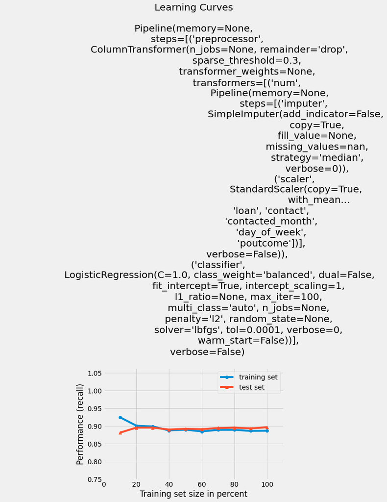

```python
from mlxtend.plotting import plot_learning_curves

plot_learning_curves(X_train, y_train, X_test, y_test, lr, scoring='recall')
```

### *Build Decision Tree Model - 2*

```python
from sklearn.tree import DecisionTreeClassifier
```

```python
clf_dt = Pipeline(steps=[('preprocessor', preprocessor),
                      ('classifier', DecisionTreeClassifier(class_weight = 'balanced'))])

dt_param_grid = {'classifier__criterion': ['entropy', 'gini'],
                 'classifier__max_depth': [8,10],
                 "classifier__min_samples_split": [5, 10],
                 "classifier__min_samples_leaf": [5, 10]
                }

dt_grid = GridSearchCV(clf_dt, param_grid=dt_param_grid, cv=2)
```

```python
%%time
dt_grid.fit(X_train,y_train)
```

```
CPU times: user 21.5 s, sys: 163 ms, total: 21.7 s
Wall time: 21.7 s
```

```
GridSearchCV(cv=2, error_score=nan,
             estimator=Pipeline(memory=None,
                                steps=[('preprocessor',
                                        ColumnTransformer(n_jobs=None,
                                                          remainder='drop',
                                                          sparse_threshold=0.3,
                                                          transformer_weights=None,
                                                          transformers=[('num',
                                                                         Pipeline(memory=None,
                                                                                  steps=[('imputer',
                                                                                          SimpleImputer(add_indicator=False,
                                                                                                        copy=True,
                                                                                                        fill_value=None,
                                                                                                        missing_values=nan,
                                                                                                        strategy='median',
                                                                                                        verbose=0)),...
                                                               min_weight_fraction_leaf=0.0,
                                                               presort='deprecated',
                                                               random_state=None,
                                                               splitter='best'))],
                                verbose=False),
             iid='deprecated', n_jobs=None,
             param_grid={'classifier__criterion': ['entropy', 'gini'],
                         'classifier__max_depth': [8, 10],
                         'classifier__min_samples_leaf': [5, 10],
                         'classifier__min_samples_split': [5, 10]},
             pre_dispatch='2*n_jobs', refit=True, return_train_score=False,
             scoring=None, verbose=0)
```

```python
dt_grid.best_params_
```

```
{'classifier__criterion': 'gini',
 'classifier__max_depth': 10,
 'classifier__min_samples_leaf': 10,
 'classifier__min_samples_split': 10}
```

```python
y_train_pred = dt_grid.predict(X_train)
y_test_pred = dt_grid.predict(X_test)
```

```python
classifcation_report_train_test(y_train, y_train_pred, y_test, y_test_pred)
```

```
            =========================================
               CLASSIFICATION REPORT FOR TRAIN DATA
            =========================================

              precision    recall  f1-score   support

           0       1.00      0.86      0.92     29229
           1       0.47      0.97      0.63      3721

    accuracy                           0.87     32950
   macro avg       0.73      0.91      0.78     32950
weighted avg       0.94      0.87      0.89     32950


            =========================================
               CLASSIFICATION REPORT FOR TEST DATA
            =========================================

              precision    recall  f1-score   support

           0       0.98      0.86      0.92      7319
           1       0.44      0.89      0.59       919

    accuracy                           0.86      8238
   macro avg       0.71      0.87      0.75      8238
weighted avg       0.92      0.86      0.88      8238
```

```
([0.954177897574124,
  0.9697386519944979,
  0.9761029411764706,
  0.9718875502008032,
  0.9704301075268817,
  0.9700892857142858,
  0.9648452426442491,
  0.9597605586963751,
  0.959231905465288,
  0.9661381349099705],
 [0.8280739934711643,
  0.8563656147986942,
  0.8715995647442872,
  0.8661588683351469,
  0.8835690968443961,
  0.8803046789989118,
  0.8988030467899891,
  0.8813928182807399,
  0.8966267682263329,
  0.8890097932535365])
```

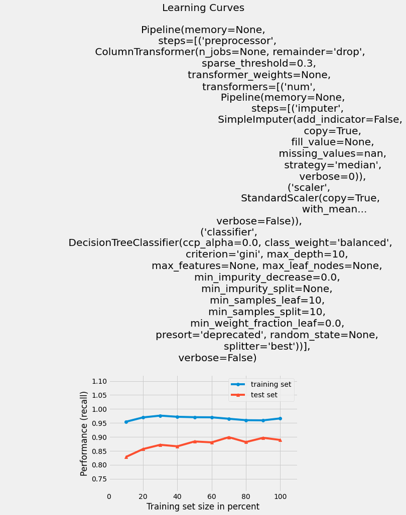

```python
# Learning Curves

plot_learning_curves(X_train, y_train, X_test, y_test, dt_grid.best_estimator_, scoring='recall')
```

```python
## so it is important that, in gridsearch we should tune the model according to our metric of interest - 'recall' here.
%%time
dt_grid1 = GridSearchCV(clf_dt, param_grid=dt_param_grid, cv=2, scoring='recall')

dt_grid1.fit(X_train, y_train)

y_train_pred = dt_grid1.predict(X_train)
y_test_pred = dt_grid1.predict(X_test)

classifcation_report_train_test(y_train, y_train_pred, y_test, y_test_pred)

# Observe that the recall value on test is improved and overfitting is reduced wrt the recall value.
```

```
            =========================================
               CLASSIFICATION REPORT FOR TRAIN DATA
            =========================================

              precision    recall  f1-score   support

           0       0.99      0.84      0.91     29229
           1       0.42      0.95      0.59      3721

    accuracy                           0.85     32950
   macro avg       0.71      0.89      0.75     32950
weighted avg       0.93      0.85      0.87     32950


            =========================================
               CLASSIFICATION REPORT FOR TEST DATA
            =========================================

              precision    recall  f1-score   support

           0       0.99      0.84      0.91      7319
           1       0.41      0.92      0.57       919

    accuracy                           0.85      8238
   macro avg       0.70      0.88      0.74      8238
weighted avg       0.92      0.85      0.87      8238

CPU times: user 21.9 s, sys: 145 ms, total: 22 s
Wall time: 22 s
```

```
([0.9622641509433962,
  0.936726272352132,
  0.9485294117647058,
  0.9578313253012049,
  0.9483870967741935,
  0.9642857142857143,
  0.9575850210164311,
  0.9664117060192883,
  0.9497784342688331,
  0.9505509271701156],
 [0.8672470076169749,
  0.8618063112078346,
  0.8998911860718172,
  0.911860718171926,
  0.9205658324265505,
  0.9205658324265505,
  0.9107725788900979,
  0.9238302502720348,
  0.9140369967355821,
  0.9227421109902068])
```

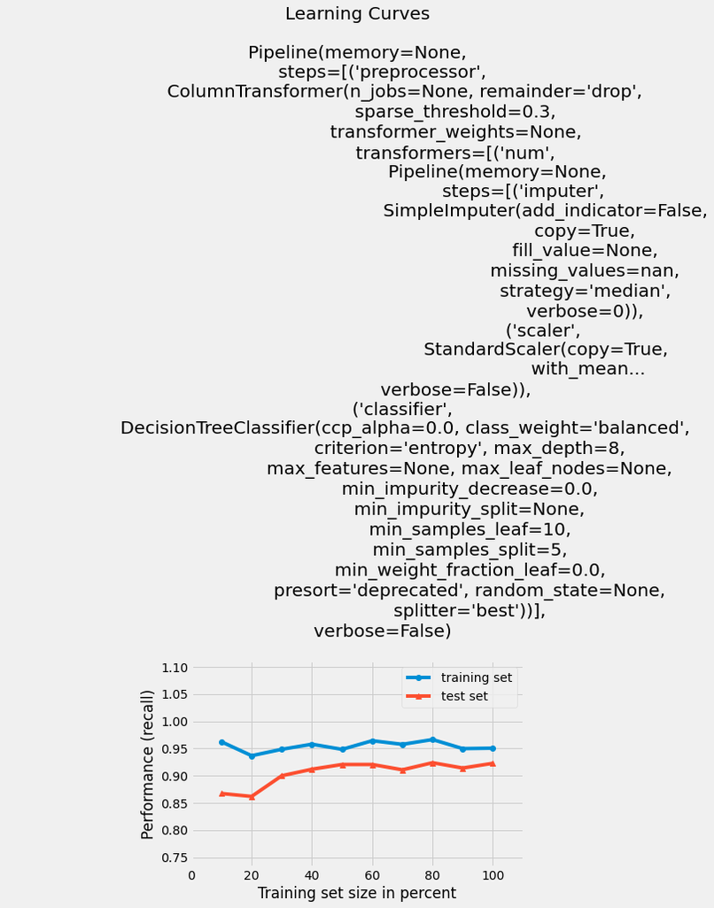

```python
plot_learning_curves(X_train, y_train, X_test, y_test, dt_grid1.best_estimator_, scoring='recall')
```

### *Build Random Forest Model - 3* (Using Stratified KFold)

**Stratified K-Folds cross-validator**

This cross-validation object is a **variation** of KFold that returns stratified folds. The folds are made by **preserving the percentage of samples for each class**.

```python
from sklearn.ensemble import RandomForestClassifier
from sklearn.model_selection import StratifiedKFold
```

```python
rf = Pipeline(steps=[('preprocessor', preprocessor),
                      ('classifier', RandomForestClassifier())])
```

```python
kfold = StratifiedKFold(n_splits=2, shuffle=True, random_state=143)

param_grid = {"classifier__n_estimators" : [150, 250, 300],
              "classifier__max_depth" : [5,8,10],
              "classifier__class_weight": ["balanced", "balanced_subsample"],
              "classifier__max_features" : [3, 5, 7],
              "classifier__min_samples_leaf" : [4, 6, 8, 10]}

rf_grid = GridSearchCV(rf, param_grid=param_grid, cv=kfold, scoring='recall')
```

```python
rf_grid.fit(X_train,y_train)
```

```python
rf_grid.best_params_
```

```
{'classifier__class_weight': 'balanced',
 'classifier__max_depth': 8,
 'classifier__max_features': 7,
 'classifier__min_samples_leaf': 6,
 'classifier__n_estimators': 150}
```

```python
y_train_pred = rf_grid.predict(X_train)
y_test_pred = rf_grid.predict(X_test)
```

```python
classifcation_report_train_test(y_train, y_train_pred, y_test, y_test_pred)
```

```
            =========================================
               CLASSIFICATION REPORT FOR TRAIN DATA
            =========================================

              precision    recall  f1-score   support

           0       0.99      0.83      0.91     29229
           1       0.42      0.95      0.58      3721

    accuracy                           0.85     32950
   macro avg       0.71      0.89      0.74     32950
weighted avg       0.93      0.85      0.87     32950


            =========================================
               CLASSIFICATION REPORT FOR TEST DATA
            =========================================

              precision    recall  f1-score   support

           0       0.99      0.83      0.90      7319
           1       0.41      0.93      0.57       919

    accuracy                           0.84      8238
   macro avg       0.70      0.88      0.74      8238
weighted avg       0.93      0.84      0.87      8238
```

```
([0.9487870619946092,
  0.936726272352132,
  0.9420955882352942,
  0.9444444444444444,
  0.946236559139785,
  0.95,
  0.9472678639663737,
  0.9494512803458597,
  0.9488921713441655,
  0.9489384574039237],
 [0.8465723612622416,
  0.8672470076169749,
  0.8835690968443961,
  0.8966267682263329,
  0.9020674646354734,
  0.9140369967355821,
  0.9216539717083787,
  0.926006528835691,
  0.9281828073993471,
  0.9303590859630033])
```

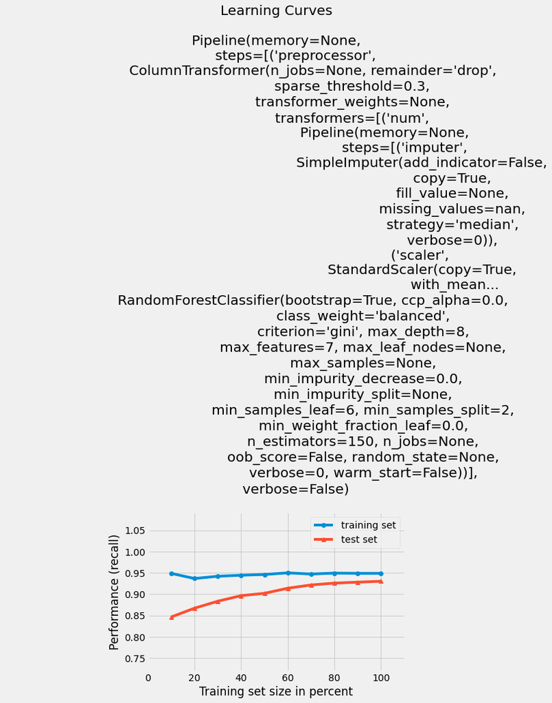

```python
plot_learning_curves(X_train, y_train, X_test, y_test, rf_grid.best_estimator_, scoring='recall')
```

### Plotting Feature Importance of RF

```python
feature_importance = FeatureImportance(rf_grid.best_estimator_)
feature_importance.plot(top_n_features=25)
```

[interactive chart not shown]

### *Build Gradient Boosting - 4*

```python
from sklearn.ensemble import GradientBoostingClassifier

from xgboost import XGBClassifier
```

```python
xgb = Pipeline(steps=[('preprocessor', preprocessor),
                      ('XGB',XGBClassifier(scale_pos_weight=100))])
```

```python
xgb_param_grid = {'XGB__scale_pos_weight' : [1, 10, 25, 50, 75, 99, 100],
                  'XGB__max_depth': [8,10,12,14],
                  'XGB__subsample': [0.8, 0.6,],
                  'XGB__max_features':[0.2, 0.3],
                  'XGB__n_estimators': [10, 20, 30]
                  }

xgb_grid = GridSearchCV(xgb, param_grid=xgb_param_grid, cv=3, scoring='recall')

xgb_grid.fit(X_train,y_train)
```

```python
xgb_grid.best_params_
```

```
{'XGB__max_depth': 8,
 'XGB__max_features': 0.2,
 'XGB__n_estimators': 20,
 'XGB__scale_pos_weight': 99,
 'XGB__subsample': 0.6}
```

```python
y_train_pred = xgb_grid.predict(X_train)
y_test_pred = xgb_grid.predict(X_test)
```

```python
classifcation_report_train_test(y_train, y_train_pred, y_test, y_test_pred)
```

```
            =========================================
               CLASSIFICATION REPORT FOR TRAIN DATA
            =========================================

              precision    recall  f1-score   support

           0       1.00      0.76      0.86     29229
           1       0.35      1.00      0.51      3721

    accuracy                           0.79     32950
   macro avg       0.67      0.88      0.69     32950
weighted avg       0.93      0.79      0.82     32950


            =========================================
               CLASSIFICATION REPORT FOR TEST DATA
            =========================================

              precision    recall  f1-score   support

           0       1.00      0.76      0.86      7319
           1       0.34      0.98      0.51       919

    accuracy                           0.79      8238
   macro avg       0.67      0.87      0.68      8238
weighted avg       0.92      0.79      0.82      8238
```

```
([1.0,
  1.0,
  0.9990808823529411,
  1.0,
  0.9994623655913979,
  0.9977678571428571,
  0.9977072984333206,
  0.9986697705354174,
  0.9979320531757755,
  0.9986562751948401],
 [0.9336235038084875,
  0.9586507072905331,
  0.955386289445049,
  0.9717083786724701,
  0.970620239390642,
  0.9760609357997824,
  0.9804134929270947,
  0.9760609357997824,
  0.9815016322089227,
  0.9804134929270947])
```

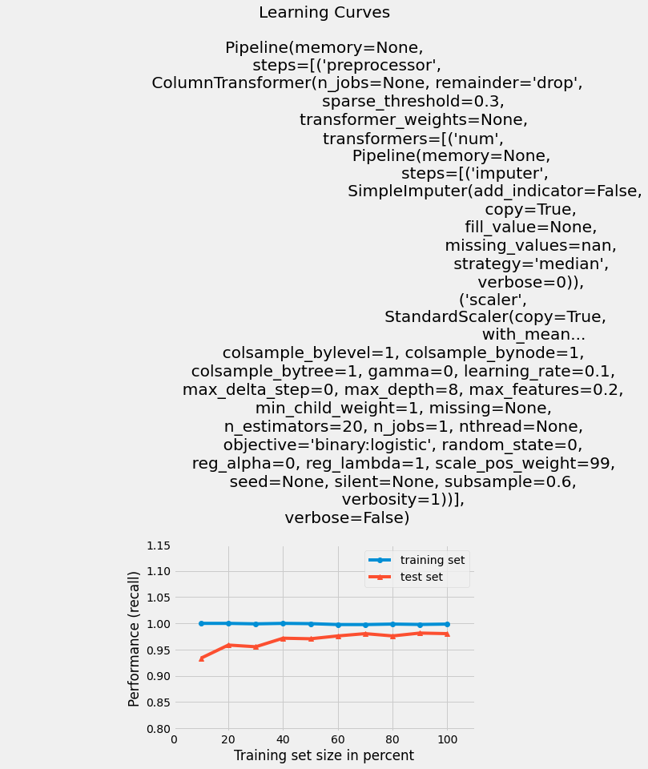

```python
plot_learning_curves(X_train, y_train, X_test, y_test, xgb_grid.best_estimator_, scoring='recall')
```

### Plotting Feature Importance of XGB

```python
feature_importance = FeatureImportance(xgb_grid.best_estimator_)
feature_importance.plot(top_n_features=25)
```

[interactive chart not shown]

### Saving the model for later use & loading it for predictions

```python
import pickle
```

```python
# Saving the model to a specific location

pickle.dump(xgb_grid.best_estimator_, open('/content/gdrive/MyDrive/Academics/Batch-89/7405 /casestudy/xgb_best_model.pickle', 'wb'))
```

```python
# Loading the model from the given location to do the predictions

xgb_loaded = pickle.load(open('/content/gdrive/MyDrive/Academics/Batch-89/7405 /casestudy/xgb_best_model.pickle', 'rb'))
```

```python
# Using the loaded model for the predictions & evaluations

y_train_pred = xgb_grid.predict(X_train)
y_test_pred = xgb_grid.predict(X_test)

classifcation_report_train_test(y_train, y_train_pred, y_test, y_test_pred)
```

```
            =========================================
               CLASSIFICATION REPORT FOR TRAIN DATA
            =========================================

              precision    recall  f1-score   support

           0       1.00      0.76      0.86     29229
           1       0.35      1.00      0.51      3721

    accuracy                           0.79     32950
   macro avg       0.67      0.88      0.69     32950
weighted avg       0.93      0.79      0.82     32950


            =========================================
               CLASSIFICATION REPORT FOR TEST DATA
            =========================================

              precision    recall  f1-score   support

           0       1.00      0.76      0.86      7319
           1       0.34      0.98      0.51       919

    accuracy                           0.79      8238
   macro avg       0.67      0.87      0.68      8238
weighted avg       0.92      0.79      0.82      8238
```

### Adjusting the Probability Threshold for Precision-Recall tradeoff

```python
from sklearn.metrics import confusion_matrix, accuracy_score, precision_score, recall_score

def get_metrics_prob(model,features,target,prob):
    temp = pd.DataFrame(model.predict_proba(features))
    temp = temp.rename(columns={0:'no1',1:'yes1'})
    temp.loc[temp['yes1'] >= prob, 'yes2'] = 1
    temp.loc[temp['yes1'] < prob, 'yes2'] = 0
    y_pred_default = model.predict(features)
    print("=="*20)
    print("WITH DEFAULT PROBABILITY THRESHOLD : 0.5")
    print("=="*20)
    cm_default = confusion_matrix(target,y_pred_default)
    print(cm_default)
    tn, fp, fn, tp = cm_default.ravel()
    print()
    print('The number of customers who have opted for term deposit which the model correctly predicted (TP): ',tp)
    print('The number of customers who have not opted for term deposit which the model correctly predicted (TN): ', tn)
    print('The number of customers who have not opted for term deposit but the model incorrectly predicted as they will opt for term deposit (FP): ', fp)
    print('The number of customers who have opted for term deposit but the model incorrectly predicted as they will not opt for term deposit (FN): ', fn)

    print()
    print("Accuracy Score is  :",accuracy_score(target,y_pred_default))
    print("Recall Score is    :",recall_score(target,y_pred_default))
    print("Precision Score is :",precision_score(target,y_pred_default))

    print()
    print("=="*23)
    print("WITH THE CHOSEN PROBABILITY THRESHOLD : ", prob)
    print("=="*23)
    cm_threshold = confusion_matrix(target,temp['yes2'])
    print(cm_threshold)
    tn1, fp1, fn1, tp1 = cm_threshold.ravel()
    print()
    print('The number of customers who have opted for term deposit which the model correctly predicted (TP): ',tp1)
    print('The number of customers who have not opted for term deposit which the model correctly predicted (TN): ', tn1)
    print('The number of customers who have not opted for term deposit but the model incorrectly predicted as they will opt for term deposit (FP): ', fp1)
    print('The number of customers who have opted for term deposit but the model incorrectly predicted as they will not opt for term deposit (FN): ', fn1)

    print()
    print("Accuracy Score is  :",accuracy_score(target,temp['yes2']))
    print("Recall Score is    :",recall_score(target,temp['yes2']))
    print("Precision Score is :",precision_score(target,temp['yes2']))
```

```python
get_metrics_prob(xgb_loaded,X_train,y_train,0.35)
```

```
========================================
WITH DEFAULT PROBABILITY THRESHOLD : 0.5
========================================
[[22204  7025]
 [    5  3716]]

The number of customers who have opted for term deposit which the model correctly predicted (TP):  3716
The number of customers who have not opted for term deposit which the model correctly predicted (TN):  22204
The number of customers who have not opted for term deposit but the model incorrectly predicted as they will opt for term deposit (FP):  7025
The number of customers who have opted for term deposit but the model incorrectly predicted as they will not opt for term deposit (FN):  5

Accuracy Score is  : 0.7866464339908953
Recall Score is    : 0.9986562751948401
Precision Score is : 0.34596406293641185

==============================================
WITH THE CHOSEN PROBABILITY THRESHOLD :  0.35
==============================================
[[21277  7952]
 [    0  3721]]

The number of customers who have opted for term deposit which the model correctly predicted (TP):  3721
The number of customers who have not opted for term deposit which the model correctly predicted (TN):  21277
The number of customers who have not opted for term deposit but the model incorrectly predicted as they will opt for term deposit (FP):  7952
The number of customers who have opted for term deposit but the model incorrectly predicted as they will not opt for term deposit (FN):  0

Accuracy Score is  : 0.7586646433990896
Recall Score is    : 1.0
Precision Score is : 0.31876981067420546
```

```python
get_metrics_prob(xgb_loaded,X_test,y_test,0.35)
```

```
========================================
WITH DEFAULT PROBABILITY THRESHOLD : 0.5
========================================
[[5577 1742]
 [  18  901]]

The number of customers who have opted for term deposit which the model correctly predicted (TP):  901
The number of customers who have not opted for term deposit which the model correctly predicted (TN):  5577
The number of customers who have not opted for term deposit but the model incorrectly predicted as they will opt for term deposit (FP):  1742
The number of customers who have opted for term deposit but the model incorrectly predicted as they will not opt for term deposit (FN):  18

Accuracy Score is  : 0.7863559116290362
Recall Score is    : 0.9804134929270947
Precision Score is : 0.3409004918653046

==============================================
WITH THE CHOSEN PROBABILITY THRESHOLD :  0.35
==============================================
[[5315 2004]
 [  10  909]]

The number of customers who have opted for term deposit which the model correctly predicted (TP):  909
The number of customers who have not opted for term deposit which the model correctly predicted (TN):  5315
The number of customers who have not opted for term deposit but the model incorrectly predicted as they will opt for term deposit (FP):  2004
The number of customers who have opted for term deposit but the model incorrectly predicted as they will not opt for term deposit (FN):  10

Accuracy Score is  : 0.7555231852391358
Recall Score is    : 0.9891186071817193
Precision Score is : 0.3120494335736354
```

### Obtaining the Predictions on the final test data

```python
df_test.head()
```

|  | age | job | marital | education | credit_default | housing | loan | contact | contacted_month | day_of_week | duration | campaign | previous | poutcome | emp_var_rate | cons_price_idx | cons_conf_idx | euribor3m | nr_employed | pdays_missing | pdays_less_5 | pdays_greater_15 | pdays_bet_5_15 |
| --- | --- | --- | --- | --- | --- | --- | --- | --- | --- | --- | --- | --- | --- | --- | --- | --- | --- | --- | --- | --- | --- | --- | --- |
| 0 | 36 | technician | married | basic.4y | no | no | no | cellular | jul | mon | 854 | 1 | 0 | nonexistent | 1.4 | 93.918 | -42.7 | 4.960 | 5228.1 | 1 | 0 | 0 | 0 |
| 1 | 39 | services | married | high.school | no | no | no | cellular | apr | thu | 598 | 2 | 2 | failure | -1.8 | 93.075 | -47.1 | 1.483 | 5099.1 | 1 | 0 | 0 | 0 |
| 2 | 54 | management | married | university.degree | no | no | yes | cellular | jul | tue | 218 | 1 | 0 | nonexistent | 1.4 | 93.918 | -42.7 | 4.961 | 5228.1 | 1 | 0 | 0 | 0 |
| 3 | 43 | blue-collar | married | basic.9y | no | yes | no | cellular | jul | fri | 226 | 1 | 0 | nonexistent | 1.4 | 93.918 | -42.7 | 4.957 | 5228.1 | 1 | 0 | 0 | 0 |
| 4 | 26 | management | single | university.degree | no | no | no | telephone | jun | mon | 72 | 3 | 0 | nonexistent | 1.4 | 94.465 | -41.8 | 4.865 | 5228.1 | 1 | 0 | 0 | 0 |

```python
y_test_final_pred = xgb_loaded.predict(df_test)
```

```python
len(y_test_final_pred)
```

```
4119
```

```python
# compare with the test target

df_test_with_target = pd.read_csv('/content/gdrive/MyDrive/Academics/Batch-89/7405 /casestudy/test_with_target.csv')

df_test_with_target['y_actual'] = df_test_with_target.y.replace({'yes':1, 'no':0})
```

```python
get_metrics_prob(xgb_loaded,df_test,df_test_with_target['y_actual'],0.35)
```

```
========================================
WITH DEFAULT PROBABILITY THRESHOLD : 0.5
========================================
[[2820  837]
 [   4  458]]

The number of customers who have opted for term deposit which the model correctly predicted (TP):  458
The number of customers who have not opted for term deposit which the model correctly predicted (TN):  2820
The number of customers who have not opted for term deposit but the model incorrectly predicted as they will opt for term deposit (FP):  837
The number of customers who have opted for term deposit but the model incorrectly predicted as they will not opt for term deposit (FN):  4

Accuracy Score is  : 0.7958242291818403
Recall Score is    : 0.9913419913419913
Precision Score is : 0.35366795366795367

==============================================
WITH THE CHOSEN PROBABILITY THRESHOLD :  0.35
==============================================
[[2704  953]
 [   3  459]]

The number of customers who have opted for term deposit which the model correctly predicted (TP):  459
The number of customers who have not opted for term deposit which the model correctly predicted (TN):  2704
The number of customers who have not opted for term deposit but the model incorrectly predicted as they will opt for term deposit (FP):  953
The number of customers who have opted for term deposit but the model incorrectly predicted as they will not opt for term deposit (FN):  3

Accuracy Score is  : 0.7679048312697256
Recall Score is    : 0.9935064935064936
Precision Score is : 0.32507082152974504
```

```python
# Note that we are doing the predictions only on the best model decided that was tuned and tested already on the train, validation data

# In real time, the target values of the test data wont be available.. but this step is given to double-check your model performance when the test target is available.
```